# Bike Sharing Forecasting

[output not shown]

[output cut: 92 more lines]

[output not shown]

[output not shown]

[output cut: 141 more lines]

[output not shown]

```python
# last run
print("Best cross-validation score: {:.2f}".format(clf_rf.best_score_))
print(clf_rf.best_params_)
```

```
Best cross-validation score: 0.95
{'bootstrap': True, 'max_depth': 30, 'max_features': 'auto', 'min_samples_leaf': 1, 'min_samples_split': 4, 'n_estimators': 500}
```

### Re-training Model with best parameters

```python
# Run randomforest on above parameters
rf_tune = RandomForestRegressor(n_estimators = 500, min_samples_split= 4, min_samples_leaf= 1, max_features = 'auto', max_depth= 30, bootstrap= True ,random_state=42, n_jobs=-1)
rf_tune.fit(x_train_refined_Xgboost,y_train)
pred_train = rf_tune.predict(x_train_refined_Xgboost)
print(mean_absolute_error(y_scaler.inverse_transform(np.array(pred_train).reshape(-1,1))
                          ,y_scaler.inverse_transform(np.array(y_train).reshape(-1,1))))
pred=rf_tune.predict(x_test_refined_Xgboost[:24])
print(mean_absolute_error(y_scaler.inverse_transform(pred.reshape(-1,1)),y_test[:24]))
```

```
8.093547838164001
64.94909167669198
```

Lets See the important features, which tuned model gives us

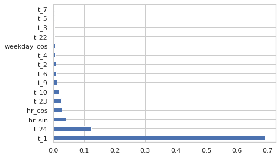

```python
feat_importances = pd.Series(rf_tune.feature_importances_, index=x_train_refined_Xgboost.columns)
feat_importances.nlargest(15).plot(kind='barh')
```

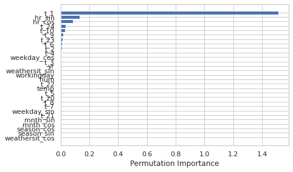

```python
from sklearn.inspection import permutation_importance
perm_importance = permutation_importance(rf_tune, x_train_refined_Xgboost, y_train)

sorted_idx = perm_importance.importances_mean.argsort()
plt.barh(x_train_refined_Xgboost.columns[sorted_idx], perm_importance.importances_mean[sorted_idx])
plt.xlabel("Permutation Importance")
```

- Train MAE is 8 and test MAe is 64

```python
x_train_refined_Xgboost_Imp_features = x_train_refined_Xgboost[['yr',  'temp', 'hum', 't_24',
       't_23', 't_22',   't_9', 't_8', 't_6', 't_5', 't_1','weathersit_sin', 'weathersit_cos', 'weekday_sin', 'weekday_cos',
        'hr_sin', 'hr_cos' ]]
x_test_refined_Xgboost_Imp_features = x_test_refined_Xgboost[['yr',  'temp', 'hum', 't_24',
       't_23', 't_22',   't_9', 't_8', 't_6','t_5', 't_1','weathersit_sin', 'weathersit_cos', 'weekday_sin', 'weekday_cos',
        'hr_sin', 'hr_cos' ]]

# Run randomforest on above parameters
rf_tune = RandomForestRegressor(n_estimators = 500, min_samples_split= 4, min_samples_leaf= 1, max_features = 'auto', max_depth= 30, bootstrap= True ,random_state=42, n_jobs=-1)
rf_tune.fit(x_train_refined_Xgboost_Imp_features,y_train)
pred_train = rf_tune.predict(x_train_refined_Xgboost_Imp_features)
print(mean_absolute_error(y_scaler.inverse_transform(np.array(pred_train).reshape(-1,1))
                          ,y_scaler.inverse_transform(np.array(y_train).reshape(-1,1))))
pred=rf_tune.predict(x_test_refined_Xgboost_Imp_features[:24])
print(mean_absolute_error(y_scaler.inverse_transform(pred.reshape(-1,1)),y_test[:24]))
```

```
8.483386532490268
64.00142557269113
```

```python
x_test_trad_15_Nov = x_test_traditional[x_test_traditional.index=='2012-11-15']
x_test_trad_15_Nov= x_test_trad_16_Nov[['yr', 'workingday', 'temp', 'hum', 't_24',
       't_23', 't_22', 't_21', 't_20',  't_10', 't_9', 't_8', 't_7', 't_6',
       't_5', 't_4', 't_3', 't_2', 't_1', 'season_sin', 'season_cos',
       'weathersit_sin', 'weathersit_cos', 'weekday_sin', 'weekday_cos',
       'mnth_sin', 'mnth_cos', 'hr_sin', 'hr_cos']]
```

[output not shown]

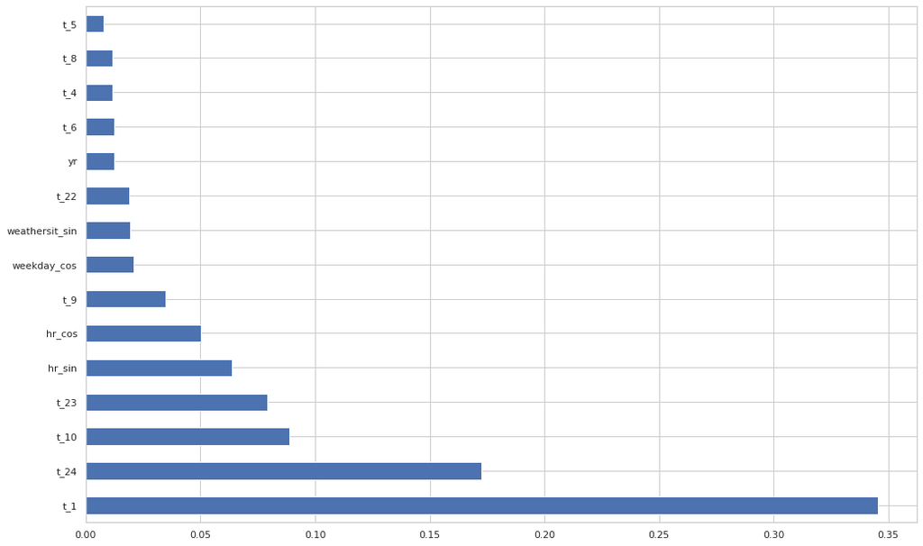

```python
from xgboost import XGBRegressor
model = XGBRegressor()
model.fit(x_train_refined_Xgboost, y_train)

(pd.Series(model.feature_importances_,x_train_refined_Xgboost.columns).nlargest(15).plot(kind='barh' ,figsize=(15,10)))
```

Random forest’s better performance paved the way for trying the tree-based XGBoost model on the data

- It is not often used for time series, especially if the base used is trees because it is difficult to catch the trend with trees, but since our data doesn’t have a very significant trend and also since it has multiple seasonalities (modeled using Fourier series) and depends significantly on exogenous variables, we can try XGboost to see how it performs on the time series data

```python
len(x_test_refined_Xgboost[:24])
```

```
24
```

Instead of numpy arrays or pandas dataFrame, XGBoost uses DMatrices. A DMatrix can contain both the features and the target

```python
dtrain = xgb.DMatrix( x_train_refined_Xgboost[:12000],y_scaler.inverse_transform(y_train[:12000].reshape(-1,1)))
dtest = xgb.DMatrix(x_train_refined_Xgboost[12000:], y_scaler.inverse_transform(y_train[12000:].reshape(-1,1)))
```

```python
d_validation = xgb.DMatrix(x_test_refined_Xgboost[:24],y_test[:24])
```

```python
params = {
    # Parameters that we are going to tune.
    'max_depth':6,
    'min_child_weight': 1,
    'eta':.3,
    'subsample': 1,
    'colsample_bytree': 1,
    # Other parameters
    'objective':'reg:linear',
}
```

the number of boosting rounds or trees to build. Its optimal value highly depends on the other parameters, and thus it should be re-tuned each time you update a parameter.

```python
params['eval_metric'] = "mae"
num_boost_round = 999
model = xgb.train(
    params,
    dtrain,
    num_boost_round=num_boost_round,
    evals=[(dtest, "Test")],
    early_stopping_rounds=10
)
```

```
[11:56:53] WARNING: /workspace/src/objective/regression_obj.cu:152: reg:linear is now deprecated in favor of reg:squarederror.
[0]	Test-mae:202.722
Will train until Test-mae hasn't improved in 10 rounds.
[1]	Test-mae:151.821
[2]	Test-mae:116.213
[3]	Test-mae:91.4154
[4]	Test-mae:74.2216
[5]	Test-mae:62.972
[6]	Test-mae:55.8357
[7]	Test-mae:51.0121
[8]	Test-mae:47.402
[9]	Test-mae:44.9945
[10]	Test-mae:43.1963
[11]	Test-mae:41.8806
[12]	Test-mae:41.2105
[13]	Test-mae:40.5808
[14]	Test-mae:39.9428
[15]	Test-mae:39.7304
[16]	Test-mae:39.5522
[17]	Test-mae:39.5331
[18]	Test-mae:39.2893
[19]	Test-mae:39.1108
[20]	Test-mae:39.0035
[21]	Test-mae:38.6332
[22]	Test-mae:38.5759
[23]	Test-mae:38.6228
[24]	Test-mae:38.5866
[25]	Test-mae:38.4601
[26]	Test-mae:38.4906
[27]	Test-mae:38.4575
[28]	Test-mae:38.516
[29]	Test-mae:38.4768
[30]	Test-mae:38.3703
[31]	Test-mae:38.3742
[32]	Test-mae:38.3988
[33]	Test-mae:38.227
[34]	Test-mae:38.2791
[35]	Test-mae:38.307
[36]	Test-mae:38.2508
[37]	Test-mae:38.4796
[38]	Test-mae:38.4397
[39]	Test-mae:38.4064
[40]	Test-mae:38.2179
[41]	Test-mae:38.2077
[42]	Test-mae:38.1724
[43]	Test-mae:38.3186
[44]	Test-mae:38.3199
[45]	Test-mae:38.3325
[46]	Test-mae:38.4025
[47]	Test-mae:38.5185
[48]	Test-mae:38.6552
[49]	Test-mae:38.6543
[50]	Test-mae:38.6634
[51]	Test-mae:38.6402
[52]	Test-mae:38.7066
Stopping. Best iteration:
[42]	Test-mae:38.1724
```

```python
print("Best MAE: {:.2f} with {} rounds".format(
                 model.best_score,
                 model.best_iteration+1))
```

```
Best MAE: 38.17 with 43 rounds
```

As you can see, we don’t need to pass a test dataset here. It’s because the cross-validation function is splitting the train dataset into nfolds and iteratively keeps one of the folds for test purposes

we will use the cv function from XGBoost. It allows us to run cross-validation on our training dataset and returns a mean MAE score

```python
cv_results = xgb.cv(
    params,
    dtrain,
    num_boost_round=num_boost_round,
    seed=42,
    nfold=5,
    metrics={'mae'},
    early_stopping_rounds=10
)
cv_results
```

[output not shown]

|  | train-mae-mean | train-mae-std | test-mae-mean | test-mae-std |
| --- | --- | --- | --- | --- |
| 0 | 109.765571 | 0.626721 | 109.953354 | 2.784902 |
| 1 | 77.852887 | 0.434863 | 78.310931 | 2.123460 |
| 2 | 56.220797 | 0.294384 | 56.901603 | 1.598967 |
| 3 | 41.878888 | 0.214238 | 42.915892 | 1.179427 |
| 4 | 32.666655 | 0.224790 | 34.175687 | 0.857363 |
| ... | ... | ... | ... | ... |
| 56 | 11.422001 | 0.140696 | 19.664047 | 0.412386 |
| 57 | 11.354045 | 0.144847 | 19.659708 | 0.396155 |
| 58 | 11.292974 | 0.145393 | 19.662738 | 0.384474 |
| 59 | 11.224902 | 0.127316 | 19.661119 | 0.377226 |
| 60 | 11.143323 | 0.126254 | 19.653496 | 0.368719 |

61 rows × 4 columns

We can get the best MAE score from cv with

```python
cv_results['test-mae-mean'].min()
```

```
19.653495799999998
```

```python
gridsearch_params = [
    (max_depth, min_child_weight)
    for max_depth in range(4,12)
    for min_child_weight in range(1,8)
]
```

```python
len(gridsearch_params)
```

```python
# Define initial best params and MAE
min_mae = float("Inf")
best_params = None
for max_depth, min_child_weight in gridsearch_params:
    print("CV with max_depth={}, min_child_weight={}".format(
                             max_depth,
                             min_child_weight))
    # Update our parameters
    params['max_depth'] = max_depth
    params['min_child_weight'] = min_child_weight
    # Run CV
    cv_results = xgb.cv(
        params,
        dtrain,
        num_boost_round=num_boost_round,
        seed=42,
        nfold=5,
        metrics={'mae'},
        early_stopping_rounds=10
    )
    # Update best MAE
    mean_mae = cv_results['test-mae-mean'].min()
    print(mean_mae)
    boost_rounds = cv_results['test-mae-mean'].argmin()
    print("\tMAE {} for {} rounds".format(mean_mae, boost_rounds))
    if mean_mae < min_mae:
        min_mae = mean_mae
        best_params = (max_depth,min_child_weight)
print("Best params: {}, {}, MAE: {}".format(best_params[0], best_params[1], min_mae))
```

[output not shown]

[output cut: 394 more lines]

[output not shown]

Next Parameters subsample and colsample_bytree

```python
params['max_depth'] = 7
params['min_child_weight'] = 6
```

subsample corresponds to the fraction of observations (the rows) to subsample at each step. By default it is set to 1 meaning that we use all rows. colsample_bytree corresponds to the fraction of features (the columns) to use. By default it is set to 1 meaning that we will use all features.

```python
gridsearch_params = [
    (subsample, colsample)
    for subsample in [i/10. for i in range(7,11)]
    for colsample in [i/10. for i in range(7,11)]
]
gridsearch_params
```

```
[(0.7, 0.7),
 (0.7, 0.8),
 (0.7, 0.9),
 (0.7, 1.0),
 (0.8, 0.7),
 (0.8, 0.8),
 (0.8, 0.9),
 (0.8, 1.0),
 (0.9, 0.7),
 (0.9, 0.8),
 (0.9, 0.9),
 (0.9, 1.0),
 (1.0, 0.7),
 (1.0, 0.8),
 (1.0, 0.9),
 (1.0, 1.0)]
```

```python
min_mae = float("Inf")
best_params = None
# We start by the largest values and go down to the smallest
for subsample, colsample in reversed(gridsearch_params):
    print("CV with subsample={}, colsample={}".format(
                             subsample,
                             colsample))
    # We update our parameters
    params['subsample'] = subsample
    params['colsample_bytree'] = colsample
    # Run CV
    cv_results = xgb.cv(
        params,
        dtrain,
        num_boost_round=num_boost_round,
        seed=42,
        nfold=5,
        metrics={'mae'},
        early_stopping_rounds=10
    )
    # Update best score
    mean_mae = cv_results['test-mae-mean'].min()
    boost_rounds = cv_results['test-mae-mean'].argmin()
    print("\tMAE {} for {} rounds".format(mean_mae, boost_rounds))
    if mean_mae < min_mae:
        min_mae = mean_mae
        best_params = (subsample,colsample)
print("Best params: {}, {}, MAE: {}".format(best_params[0], best_params[1], min_mae))
```

[output not shown]

[output cut: 58 more lines]

[output not shown]

```python
params['subsample'] = 1.0
params['colsample_bytree'] = 1.0
```

Parameter ETA The ETA parameter controls the learning rate. It corresponds to the shrinkage of the weights associated to features after each round, in other words it defines the amount of "correction" we make at each step

```python
%time
# This can take some time…
min_mae = float("Inf")
best_params = None
for eta in [.3, .2, .1, .05, .01, .005]:
    print("CV with eta={}".format(eta))
    # We update our parameters
    params['eta'] = eta
    # Run and time CV
    %time cv_results = xgb.cv( params, dtrain,num_boost_round=num_boost_round,seed=42, nfold=5,metrics=['mae'], early_stopping_rounds=10          )
    # Update best score
    mean_mae = cv_results['test-mae-mean'].min()
    boost_rounds = cv_results['test-mae-mean'].argmin()
    print("\tMAE {} for {} rounds\n".format(mean_mae, boost_rounds))
    if mean_mae < min_mae:
        min_mae = mean_mae
        best_params = eta
print("Best params: {}, MAE: {}".format(best_params, min_mae))
```

[output not shown]

[output cut: 8 more lines]

```
CPU times: user 2min 19s, sys: 444 ms, total: 2min 20s
Wall time: 2min 19s
	MAE 18.370829399999998 for 998 rounds

CV with eta=0.005
[12:16:52] WARNING: /workspace/src/objective/regression_obj.cu:152: reg:linear is now deprecated in favor of reg:squarederror.
[12:16:52] WARNING: /workspace/src/objective/regression_obj.cu:152: reg:linear is now deprecated in favor of reg:squarederror.
[12:16:52] WARNING: /workspace/src/objective/regression_obj.cu:152: reg:linear is now deprecated in favor of reg:squarederror.
[12:16:52] WARNING: /workspace/src/objective/regression_obj.cu:152: reg:linear is now deprecated in favor of reg:squarederror.
[12:16:52] WARNING: /workspace/src/objective/regression_obj.cu:152: reg:linear is now deprecated in favor of reg:squarederror.
CPU times: user 2min 27s, sys: 410 ms, total: 2min 27s
Wall time: 2min 27s
	MAE 18.8082336 for 998 rounds

Best params: 0.01, MAE: 18.370829399999998
```

```python
params['eta'] = 0.01
params
```

```
{'colsample_bytree': 1.0,
 'eta': 0.01,
 'eval_metric': 'mae',
 'max_depth': 7,
 'min_child_weight': 6,
 'objective': 'reg:linear',
 'subsample': 1.0}
```

Let’s train a model with it and see how well it does on our test set!

```python
model = xgb.train(
    params,
    dtrain,
    num_boost_round=num_boost_round,
    evals=[(dtest, "Test")],
    early_stopping_rounds=10
)
```

[output not shown]

[output cut: 756 more lines]

```
[794]	Test-mae:34.6225
[795]	Test-mae:34.6196
[796]	Test-mae:34.6151
[797]	Test-mae:34.6174
[798]	Test-mae:34.6209
[799]	Test-mae:34.6198
[800]	Test-mae:34.6183
[801]	Test-mae:34.62
[802]	Test-mae:34.6276
[803]	Test-mae:34.6254
[804]	Test-mae:34.6234
[805]	Test-mae:34.6214
[806]	Test-mae:34.6205
Stopping. Best iteration:
[796]	Test-mae:34.6151
```

Best MAE is 34

we found the best number of rounds, our model has been trained with more rounds than optimal, thus before using it for predictions, we should retrain it with the good number of rounds. Since we now the exact best num_boost_round, we don't need the early_stopping_round anymore

```python
num_boost_round = model.best_iteration + 1
```

```python
best_model = xgb.train(
    params,
    dtrain,
    num_boost_round=num_boost_round,    evals=[(dtest, "Test")])
```

[output not shown]

[output cut: 743 more lines]

```
[782]	Test-mae:34.6395
[783]	Test-mae:34.642
[784]	Test-mae:34.6361
[785]	Test-mae:34.6365
[786]	Test-mae:34.6339
[787]	Test-mae:34.6295
[788]	Test-mae:34.6311
[789]	Test-mae:34.6281
[790]	Test-mae:34.6341
[791]	Test-mae:34.6328
[792]	Test-mae:34.6309
[793]	Test-mae:34.6245
[794]	Test-mae:34.6225
[795]	Test-mae:34.6196
[796]	Test-mae:34.6151
```

```python
d_validation = xgb.DMatrix(x_test_refined_Xgboost[:24],y_test[:24])
```

```python
mean_absolute_error(best_model.predict(d_validation), y_test[:24])
```

```
35.766134828329086
```

And it seems to have learned the data patterns along with multiple seasonalities very well

```python
d_validation = xgb.DMatrix(x_test_trad_15_Nov)
```

```python
best_model.save_model("xgboost.model")
```

```python
loaded_model = xgb.Booster()
loaded_model.load_model("xgboost.model")
# And use it for predictions.
loaded_model.predict(d_validation)
```

```
[12:37:50] WARNING: /workspace/src/objective/regression_obj.cu:152: reg:linear is now deprecated in favor of reg:squarederror.
```

```
array([ 51.7713   ,  21.400488 ,  11.451786 ,   3.2230747,   4.814116 ,
        46.75722  , 138.26277  , 429.79413  , 596.7866   , 364.76215  ,
       241.23416  , 206.13347  , 265.42273  , 247.7683   , 259.2122   ,
       270.54904  , 403.61804  , 672.07794  , 618.1639   , 434.84268  ,
       323.89563  , 253.84468  , 192.94777  , 121.61991  ], dtype=float32)
```

```python
def mean_absolute_percentage_error(y_true, y_pred):
 y_true, y_pred = np.array(y_true), np.array(y_pred)
 return np.mean(np.abs((y_true - y_pred) / y_true)) * 100
 accuracy=100-mape
 print('Accuracy:', round(accuracy,2),'%.')
```

```python
mean_absolute_percentage_error(loaded_model.predict(d_validation), y_test)
```

1. Assume that the revenue per rental is 12 euro/Rental.
2. Each bicycle has costs of y 10 euro/Rental
3. I will check residuals from my validation set (after predicting demand of bike sharing). Consideing the residuals as random shocks affecting the average values and resulting in real observed values. Assuming this random variable is gaussian distributed.
4. let's Simulate the profit with a fixed number of `nmax` bicycles say 4, for the next 24 hrs given that the real observed values are expected to be different from average predicted values.

```python
Predicted_results = Trained_model_lstm.predict(val_rescaled_1_nov)
Predicted_results_Inv_trans = y_scaler.inverse_transform(Predicted_results)
#timeseries_evaluation_metrics_func(y_test_15_nov,Predicted_results_Inv_trans[0])
pred =Predicted_results_Inv_trans[0]
pred
```

```
array([ 29.231655 ,   7.9016175,   9.213968 ,   1.8461155,   9.087922 ,
        34.690235 , 127.56065  , 379.54172  , 628.4044   , 310.94937  ,
       150.65652  , 177.78201  , 221.77194  , 220.77873  , 198.56018  ,
       221.09435  , 327.216    , 605.1717   , 581.4398   , 398.83652  ,
       274.73856  , 206.22935  , 168.34096  , 101.32557  ], dtype=float32)
```

```python
y_test_15_nov
```

```
array([ 34.,  16.,   7.,   2.,   5.,  37., 147., 410., 646., 323., 153.,
       166., 213., 217., 201., 217., 342., 563., 573., 386., 285., 224.,
       153., 125.])
```

```python
residuals_df = pd.DataFrame({ 'Actual_bikes':y_test_15_nov, 'Predicted_bikes':pred })
```

```python
residuals_df['residuals'] = np.round(residuals_df.Actual_bikes-residuals_df.Predicted_bikes)
residuals_df[:4]
```

|  | Actual_bikes | Predicted_bikes | residuals |
| --- | --- | --- | --- |
| 0 | 34.0 | 29.231655 | 5.0 |
| 1 | 16.0 | 7.901618 | 8.0 |
| 2 | 7.0 | 9.213968 | -2.0 |
| 3 | 2.0 | 1.846115 | 0.0 |

```python
mu = np.mean(residuals_df.residuals)
sigma = np.std(residuals_df.residuals)
```

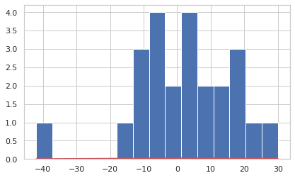

```python
pdf = stats.norm.pdf(sorted(residuals_df.residuals), mu, sigma)
plt.hist(residuals_df.residuals, bins=15)
plt.plot(sorted(residuals_df.residuals), pdf, color='r', linewidth=2)
plt.show()
```

Let's Simulate our model performance for a day

```python
# Let's say
revenue_per_rental = 12
cost_per_rental = 10
```

```python
residuals_df['Expected_bikes_avilable_prhour'] = np.ceil((residuals_df['Actual_bikes']/4))
residuals_df['Predicted_bikes_avilable_prhour'] = np.ceil((residuals_df['Predicted_bikes']/4))
residuals_df['Residual_Bike'] = np.floor((residuals_df['residuals']/4))
```

```python
residuals_df[:10]
```

|  | Actual_bikes | Predicted_bikes | residuals | Expected_bikes_avilable_prhour | Predicted_bikes_avilable_prhour | Residual_Bike |
| --- | --- | --- | --- | --- | --- | --- |
| 0 | 34.0 | 29.231655 | 5.0 | 9.0 | 8.0 | 1.0 |
| 1 | 16.0 | 7.901618 | 8.0 | 4.0 | 2.0 | 2.0 |
| 2 | 7.0 | 9.213968 | -2.0 | 2.0 | 3.0 | -1.0 |
| 3 | 2.0 | 1.846115 | 0.0 | 1.0 | 1.0 | 0.0 |
| 4 | 5.0 | 9.087922 | -4.0 | 2.0 | 3.0 | -1.0 |
| 5 | 37.0 | 34.690235 | 2.0 | 10.0 | 9.0 | 0.0 |
| 6 | 147.0 | 127.560654 | 19.0 | 37.0 | 32.0 | 4.0 |
| 7 | 410.0 | 379.541718 | 30.0 | 103.0 | 95.0 | 7.0 |
| 8 | 646.0 | 628.404419 | 18.0 | 162.0 | 158.0 | 4.0 |
| 9 | 323.0 | 310.949371 | 12.0 | 81.0 | 78.0 | 3.0 |

```python
Simulate_profit_30days = residuals_df.iloc[:]
Simulate_profit_30days[:2]
```

|  | Actual_bikes | Predicted_bikes | residuals | Expected_bikes_avilable_prhour | Predicted_bikes_avilable_prhour | Residual_Bike |
| --- | --- | --- | --- | --- | --- | --- |
| 0 | 34.0 | 29.231655 | 5.0 | 9.0 | 8.0 | 1.0 |
| 1 | 16.0 | 7.901618 | 8.0 | 4.0 | 2.0 | 2.0 |

```python
Simulate_profit_30days['revenue_perhour'] = Simulate_profit_30days.apply(lambda x: x['Predicted_bikes_avilable_prhour']* revenue_per_rental if x['Residual_Bike']
                                                                        > 0 else (x['Expected_bikes_avilable_prhour']* revenue_per_rental+( x['Residual_Bike']* cost_per_rental)),axis=1)
```

```python
Simulate_profit_30days['actual_revenue_expected'] = Simulate_profit_30days['Expected_bikes_avilable_prhour']* revenue_per_rental
```

```python
Simulate_profit_30days[:4]
```

|  | Actual_bikes | Predicted_bikes | residuals | Expected_bikes_avilable_prhour | Predicted_bikes_avilable_prhour | Residual_Bike | revenue_perhour | actual_revenue_expected |
| --- | --- | --- | --- | --- | --- | --- | --- | --- |
| 0 | 34.0 | 29.231655 | 5.0 | 9.0 | 8.0 | 1.0 | 96.0 | 108.0 |
| 1 | 16.0 | 7.901618 | 8.0 | 4.0 | 2.0 | 2.0 | 24.0 | 48.0 |
| 2 | 7.0 | 9.213968 | -2.0 | 2.0 | 3.0 | -1.0 | 14.0 | 24.0 |
| 3 | 2.0 | 1.846115 | 0.0 | 1.0 | 1.0 | 0.0 | 12.0 | 12.0 |

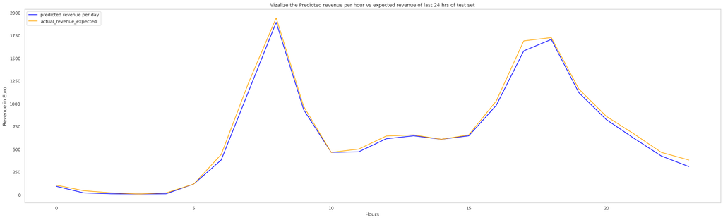

```python
plt.figure(figsize=(28,9))
plt.title('Vizalize the Predicted revenue per hour vs expected revenue of last 24 hrs of test set')

ax1 = Simulate_profit_30days.revenue_perhour.plot(color='blue', grid=False, label='predicted revenue per day')
ax2 = Simulate_profit_30days.actual_revenue_expected.plot(color='orange', grid=False,  label='actual_revenue_expected')

plt.legend(loc="upper left")

plt.xlabel("Hours")
plt.ylabel("Revenue in Euro")
plt.show()
```

```python
pip freeze > requirements.txt
```

```python
%%shell
jupyter nbconvert --to html /content/Bike_Sharing_Feature_Engineering_Modelling_Conclusion.ipynb
```

```
[NbConvertApp] Converting notebook /content/Bike_Sharing_Feature_Engineering_Modelling_Conclusion.ipynb to html
[NbConvertApp] Writing 2616376 bytes to /content/Bike_Sharing_Feature_Engineering_Modelling_Conclusion.html
```

## References

[1] Lichman, M. (2013). UCI Machine Learning Repository [http://archive.ics.uci.edu/ml]. Irvine, CA: University of California, School of Information and Computer Science.